# MEA Acute SC Evaluation

Amy Carpenter

June 27, 2022

# Purpose —-

To decide if we are ready to release the acute sc data in tcpl to the public. Specifically, * To understand how the tcpl acute sc results aligned with what was published in Strickland, et al 2018 * To understand how the tcpl acute sc results align with the samples that were / were not retested in the mc * Evaluate how well the acute sc results behave as we expect * If the tcpl results are close enough to what was published in Strickland 2018, use those analysis to validate * Else, identify your own assay controls and evaluate

# Compare Strickland 2018 and tcpl sc results —-

## Prepare tables to compare —-

```r
# Load strickland results
strickland.res <- as.data.table(read.xlsx('investigations/sc_and_cytotox_endpoints_July2022/data/Stricklandetal2018_AcuteSC-Supplement1.xlsx', sheet = 1))

# Load tcpl results
# load('../../mea_nfa_vs_acute/data/mea_acute_and_dev_sc2_2022-02-10.RData')
# sc2 <- sc2[assay_type == 'acute']
load('investigations/sc_and_cytotox_endpoints_July2022/data/sc0_and_sc2_invitrodb_05042022_2022-08-03.RData')

head(strickland.res)
```

```
##    Table.S1..DSSTox.list.of.MEA.summarized.hit.calls.for.1056.unique.tested.chemicals
## 1:                                                                DSSTox_Substance_Id
## 2:                                                                      DTXSID5020281
## 3:                                                                      DTXSID8020961
## 4:                                                                      DTXSID0021834
## 5:                                                                      DTXSID7030698
## 6:                                                                      DTXSID5021837
##             X2                      X3              X4
## 1: DSSTox_GSID          Substance_Name Substance_CASRN
## 2:       20281 1-Chloro-4-nitrobenzene        100-00-5
## 3:       20961          4-Nitroaniline        100-01-6
## 4:       21834           4-Nitrophenol        100-02-7
## 5:       30698      alpha-Cyclodextrin      10016-20-3
## 6:       21837 N,N-Diethylethanolamine        100-37-8
##                                                                                                                                                                                                                                                     X5
```

[output cut: 20 more lines]

```r
new.colnames <- strickland.res[1,]
setnames(strickland.res, old = names(strickland.res), new = unlist(new.colnames))
strickland.res <- strickland.res[2:nrow(strickland.res)]
```

Total chemicals in TCPL sc:

```r
sc2[!is.na(dsstox_substance_id), length(unique(dsstox_substance_id))]
```

```
## [1] 1055
```

Total samples in TCPL sc:

```r
sc2[!is.na(spid), length(unique(spid))]
```

```
## [1] 1104
```

Total chemicals in strickland 2018

```r
strickland.res[grepl('^DT',DSSTox_Substance_Id), length(unique(DSSTox_Substance_Id))]
```

```
## [1] 1056
```

```r
# what's different?
strickland.res[!DSSTox_Substance_Id %in% sc2$dsstox_substance_id, .(DSSTox_Substance_Id, Substance_Name, MEA_hit_detail)]
```

```
##    DSSTox_Substance_Id              Substance_Name MEA_hit_detail
## 1:      DTXSID60873651  (+)-Bicuculline methiodide             up
```

Ah, yes. We probably just don’t have a sample ID for Bicuculline in tcpl, so it wasn’t entered with a dtxsid Does the MEA hit only refer to the MFR, and not the LDH or AB?  
From abstract: “only 8 compounds decreased cell viability” - so this won’t affect very many  
Also from paragraph “Assay Data Analysis”, it’s clear that in supplementary table 1 the hits refer to the normalized mean firing rate hit calls

```r
# In tcpl, any conflict regarding hit direction?
sc2[grepl('MFR',aenm), .N, by = .(aenm)]
```

```
##                      aenm    N
## 1: CCTE_Shafer_MEA_MFR_up 1104
## 2: CCTE_Shafer_MEA_MFR_dn 1104
```

```r
sc2[grepl('MFR',aenm), .(sum(hitc %in% 1)), by = .(spid)][V1 > 1]
```

```
## Empty data.table (0 rows and 2 cols): spid,V1
```

```r
# empty, good

# Any cases of multiple spid tested for a given chem?
sc2[, .(length(unique(spid))), by = .(dsstox_substance_id)][V1 > 1]
```

```
##     dsstox_substance_id V1
##  1:                <NA>  3
##  2:       DTXSID8035180  6
##  3:       DTXSID7020182  6
##  4:       DTXSID3031864  6
##  5:       DTXSID0034695  6
##  6:       DTXSID0032520  6
##  7:       DTXSID8024238  6
##  8:       DTXSID5032498  6
##  9:       DTXSID0032493  6
## 10:       DTXSID5020154  6
## 11:       DTXSID9022364  2
```

```r
# 10 cases

# What does strickland table look liek in these cases?
check.chem <- sc2[, .(length(unique(spid))), by = .(dsstox_substance_id)][V1 > 1 & !is.na(dsstox_substance_id), dsstox_substance_id]
strickland.res[DSSTox_Substance_Id %in% check.chem]
```

```
##     DSSTox_Substance_Id DSSTox_GSID             Substance_Name Substance_CASRN
##  1:       DTXSID5020154       20154                 Clorophene        120-32-1
##  2:       DTXSID0032520       32520               Azoxystrobin     131860-33-8
##  3:       DTXSID3031864       31864                       PFOS       1763-23-1
##  4:       DTXSID8024238       24238                   Oryzalin      19044-88-3
##  5:       DTXSID5032498       32498                  Triclosan       3380-34-5
##  6:       DTXSID9022364       22364 5alpha-Dihydrotestosterone        521-18-6
##  7:       DTXSID0032493       32493                Triadimenol      55219-65-3
##  8:       DTXSID8035180       35180                  Allethrin        584-79-2
##  9:       DTXSID7020182       20182                Bisphenol A         80-05-7
## 10:       DTXSID0034695       34695                   Mancozeb       8018-01-7
##                                                         Structure_SMILE
##  1:                                      OC1=C(CC2=CC=CC=C2)C=C(Cl)C=C1
##  2:          CO\\C=C(\\C(=O)OC)C1=CC=CC=C1OC1=CC(OC2=CC=CC=C2C#N)=NC=N1
##  3: OS(=O)(=O)C(F)(F)C(F)(F)C(F)(F)C(F)(F)C(F)(F)C(F)(F)C(F)(F)C(F)(F)F
```

[output cut: 18 more lines]

```r
# hemm, looks like just 1 sample is shown

# Agreement with Strickland?
# Collapse by sample
tcpl.res <- sc2[grepl('MFR',aenm), .(MEA_hit = ifelse(any(hitc %in% 1), 1, 0),
                                     MEA_hit_detail = ifelse(any(hitc %in% 1), aenm[hitc %in% 1], '0')),
                by = .(dsstox_substance_id, casn, chnm, spid)]
tcpl.res[, MEA_hit_detail := sub('CCTE_Shafer_MEA_MFR_','',MEA_hit_detail)]
tcpl.res[MEA_hit_detail == 'dn', MEA_hit_detail := 'down']

comp.res <- merge(strickland.res, tcpl.res, by.x = 'DSSTox_Substance_Id', by.y = 'dsstox_substance_id', all = T, suffixes = c('.strickland','.tcpl'))
# Note: tcpl.res is broken down by spid
# So rows in stricklnad.res will be duplicated where there are multiple spid mapped to a given dtxsid


# Check for any that didn't map
tcpl.res[is.na(MEA_hit)]
```

```
## Empty data.table (0 rows and 6 cols): dsstox_substance_id,casn,chnm,spid,MEA_hit,MEA_hit_detail
```

```r
strickland.res[is.na(MEA_hit)]
```

```
## Empty data.table (0 rows and 9 cols): DSSTox_Substance_Id,DSSTox_GSID,Substance_Name,Substance_CASRN,Structure_SMILE,MEA_hit_detail...
```

```r
# none were NA beforehand
comp.res[is.na(MEA_hit.tcpl)]
```

```
##    DSSTox_Substance_Id DSSTox_GSID              Substance_Name Substance_CASRN
## 1:      DTXSID60873651      873651  (+)-Bicuculline methiodide      40709-69-1
##                                                                   Structure_SMILE
## 1:  [I-].[H][C@]1(OC(=O)C2=C1C=CC1=C2OCO1)[C@]1([H])C2=C(CC[N+]1(C)C)C=C1OCOC1=C2
##    MEA_hit_detail.strickland MEA_hit.strickland Column Headers Definitions casn
## 1:                        up                  1           <NA>        <NA> <NA>
##    chnm spid MEA_hit.tcpl MEA_hit_detail.tcpl
## 1: <NA> <NA>           NA                <NA>
```

```r
# hmm, this is bicuculline
comp.res[is.na(MEA_hit.strickland)]
```

```
##    DSSTox_Substance_Id DSSTox_GSID Substance_Name Substance_CASRN
## 1:                <NA>        <NA>           <NA>            <NA>
## 2:                <NA>        <NA>           <NA>            <NA>
## 3:                <NA>        <NA>           <NA>            <NA>
##    Structure_SMILE MEA_hit_detail.strickland MEA_hit.strickland Column Headers
## 1:            <NA>                      <NA>               <NA>           <NA>
## 2:            <NA>                      <NA>               <NA>           <NA>
## 3:            <NA>                      <NA>               <NA>           <NA>
##    Definitions casn chnm        spid MEA_hit.tcpl MEA_hit_detail.tcpl
## 1:        <NA> <NA> <NA> BICUCULLINE            1                  up
## 2:        <NA> <NA> <NA>        DMSO            0                   0
## 3:        <NA> <NA> <NA>       LYSIS            1                down
```

```r
# all the NA dtxsid's from tcpl
# Let's assign the dtxsid for bic to tcpl.res
tcpl.res[spid == 'BICUCULLINE', dsstox_substance_id := 'DTXSID60873651']
comp.res <- merge(strickland.res, tcpl.res[!is.na(dsstox_substance_id)], by.x = 'DSSTox_Substance_Id', by.y = 'dsstox_substance_id', all = T, suffixes = c('.strickland','.tcpl'))
comp.res[is.na(MEA_hit.tcpl)]
```

```
## Empty data.table (0 rows and 14 cols): DSSTox_Substance_Id,DSSTox_GSID,Substance_Name,Substance_CASRN,Structure_SMILE,MEA_hit_detail.strickland...
```

```r
comp.res[is.na(MEA_hit.strickland)]
```

```
## Empty data.table (0 rows and 14 cols): DSSTox_Substance_Id,DSSTox_GSID,Substance_Name,Substance_CASRN,Structure_SMILE,MEA_hit_detail.strickland...
```

```r
# cool, empty now
```

## Compare results!

```r
comp.res[, .N, by = .(MEA_hit.strickland, MEA_hit.tcpl)]
```

```
##    MEA_hit.strickland MEA_hit.tcpl   N
## 1:                  0            0 729
## 2:                  1            1 359
## 3:                  1            0  13
## 4:                  0            1   1
```

```r
comp.res[, .(num_spid = .N), by = .(MEA_hit_detail.strickland, MEA_hit_detail.tcpl)][order(-num_spid)]
```

```
##    MEA_hit_detail.strickland MEA_hit_detail.tcpl num_spid
## 1:                         0                   0      729
## 2:                      down                down      340
## 3:                        up                  up       19
## 4:                      down                   0        9
## 5:                        up                   0        4
## 6:                         0                down        1
```

Sweet, the vast majority of cases agree!

Check out the few cases that don’t agree

```r
comp.res[, num_spid_tested := .N, by = .(DSSTox_Substance_Id)]
comp.res[MEA_hit_detail.strickland != MEA_hit_detail.tcpl, .(Substance_Name, spid, num_spid_tested, strickland = MEA_hit_detail.strickland, tcpl = MEA_hit_detail.tcpl)]
```

```
##                 Substance_Name         spid num_spid_tested strickland tcpl
##  1:                Triadimenol TP0001186A04               6       down    0
##  2:               Azoxystrobin TP0001243D03               6       down    0
##  3:               Azoxystrobin TP0001243G03               6       down    0
##  4:                   Mancozeb TP0001184H02               6       down    0
##  5:                   Mancozeb TP0001185F01               6       down    0
##  6:                   Mancozeb TP0001187H07               6       down    0
##  7:                   Mancozeb TP0001236B07               6       down    0
##  8:                   Mancozeb TP0001237C11               6       down    0
##  9:               Thiamethoxam TP0001184G01               1         up    0
## 10:                       PFOS TP0001187C03               6         up    0
## 11:                       PFOS TP0001238E01               6         up    0
## 12:                       PFOS TP0001241B02               6         up    0
## 13: 5alpha-Dihydrotestosterone TP0001237C02               2       down    0
## 14:         3,4-Diaminotoluene TP0001237B08               1          0 down
```

in all but 2 cases, there were multiple spid tested… so probably some agreed, adn some did not

```r
comp.res[, plot_name := paste0(Substance_Name,' - ',spid)]

plotdat <- melt(comp.res[num_spid_tested > 1], id.vars = c('Substance_Name','spid'), measure.vars = c('MEA_hit_detail.tcpl','MEA_hit_detail.strickland'))
plotdat[, variable := sub("MEA_hit_detail\\.","",variable)]
plotdat[variable == 'strickland', variable := 'strickland\n(spid agnostic)']
```

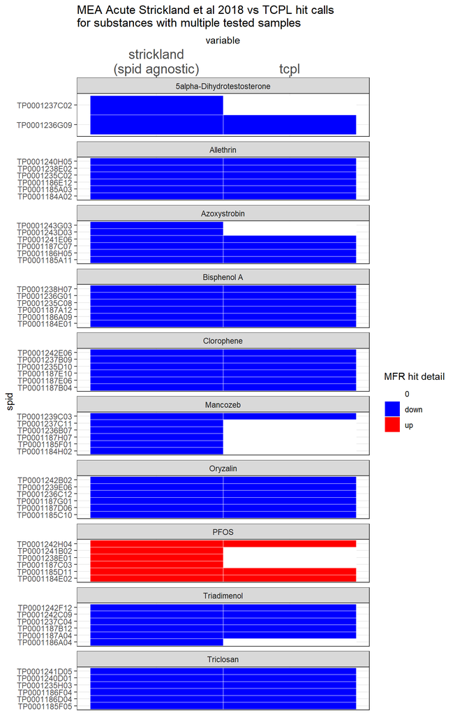

```r
ggplot(plotdat, aes(x = variable, y = spid)) +
  geom_tile(aes(fill = value), col = 'white')+
  scale_fill_manual(values = c('0' = 'white',
                                 'down' = 'blue',
                                 'up' = 'red'),
                    name = 'MFR hit detail')+
  scale_x_discrete(position = 'top')+
  facet_wrap(vars(Substance_Name), ncol = 1,
             scales = 'free_y')+
  theme_bw()+
  ggtitle('MEA Acute Strickland et al 2018 vs TCPL hit calls\nfor substances with multiple tested samples')+
  theme(axis.text.x = element_text(size = 15))
```

Looks like in every case, one of the samples in tcpl isn’t active  
12 of the mismatches in hit can be explained by the fact that for the 2018 manuscript, they probably just used the most active sample That leaves only 2 truly conflicting hits - that’s pretty minimal!!

The 2 spid’s with conflicting hit calls

```r
check.spid <- comp.res[MEA_hit_detail.strickland != MEA_hit_detail.tcpl & num_spid_tested == 1, spid]
comp.res[spid %in% check.spid, .(chnm, spid, MEA_hit_detail.strickland, MEA_hit_detail.tcpl)]
```

```
##                  chnm         spid MEA_hit_detail.strickland
## 1:       Thiamethoxam TP0001184G01                        up
## 2: 3,4-Diaminotoluene TP0001237B08                         0
##    MEA_hit_detail.tcpl
## 1:                   0
## 2:                down
```

```r
sc2[spid %in% check.spid & grepl('MFR',aenm), .(chnm, spid, aenm, max_med, bmad, coff, tcpl_hitc = hitc)]
```

```
##                  chnm         spid                   aenm   max_med    bmad
## 1:       Thiamethoxam TP0001184G01 CCTE_Shafer_MEA_MFR_up  20.39686 21.6295
## 2:       Thiamethoxam TP0001184G01 CCTE_Shafer_MEA_MFR_dn -20.39686 21.6295
## 3: 3,4-Diaminotoluene TP0001237B08 CCTE_Shafer_MEA_MFR_up -64.90577 21.6295
## 4: 3,4-Diaminotoluene TP0001237B08 CCTE_Shafer_MEA_MFR_dn  64.90577 21.6295
##       coff tcpl_hitc
## 1: 21.6295         0
## 2: 64.8885         0
## 3: 21.6295         0
## 4: 64.8885         1
```

Thiamethoxam is pretty close to being an up hit in tcpl  
3,4-Diaminotoluene looks VEEERY borderline for the down hit  
So these cases that differed from Strickland 2018 are quite borderline

Conclusion:  
Out of the 1055 chemicals and 1104 sample IDs, the tcpl and strickland 2018 acute sc results are VERY comparable  
There are 2 borderline cases where a hit call is added or removed  
And 12 other spid’s that were inactive, but at least 1 sample of the given chemical was active, so the chemical was reported as active in Strickland 2018  
(Note that the only acute SC data in tcpl to date comes from the ToxCast library screening that was published in Strickland 2018)  
So at the sample level, 1090/1104 = 98.7% of the samples have the same MFR hit call (whether up, down, or no hit)  
Therefore, I think we can rely on the analyses of the the MEA acute endpoints as previously published (no new analyses are needed)